# Hands-on workshop: Bayesian networks

# 1 `bnlearn` package

The `bnlearn` package is one of the most complete and popular package for Bayesian Networks available to the date in `R`.

First we should install and load the package.

**Please make sure that you either download or compile at least `bnelarn 4.2.x` as previous versions might have some bugs. check the version of `bnlearn` pakcage by typing `packageVersion("bnlearn")` in `R` console.**

You should check out the documentation that is available online [[Link]](http://bnlearn.com/). It contains nice examples and additional use cases beyond this tutorial. If you are interested in this topic, there are a couple of related books written by the author of the package, you can find the references in the mentioned website.

## 1.1 Install R package `bnlearn`

### Method 1 : Graphic User Interface

- Open R

[figure not shown]

- Open Package Installer
  - Menu / Packages & Data / Package Installer

[figure not shown]

- install package `bnlearn`

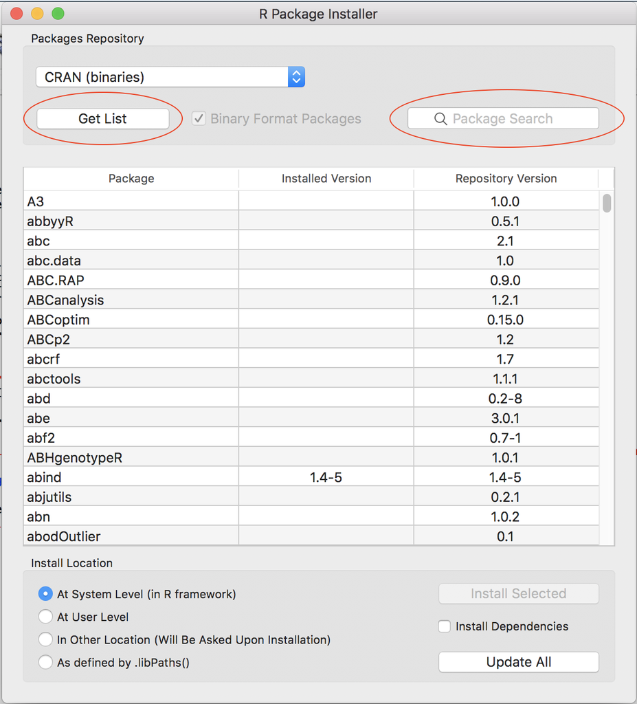

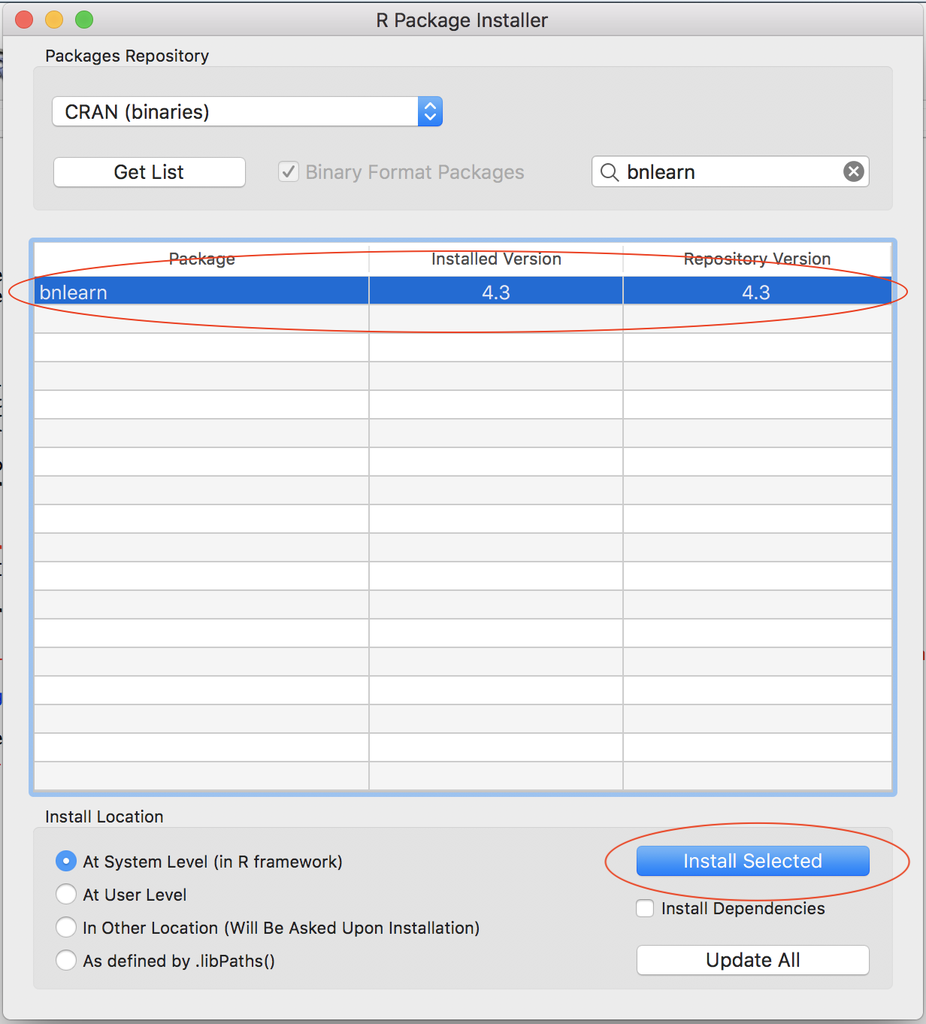

  - Click on “Get List”
    - Choose a CRAN mirror (you are free to choose any cran mirror)
  - search `bnlearn`
  - select `bnlearn`
    - the selected line turns to blue
    - the “install Selected” buttom turns to blue
  - click on “install Selected” buttom
- close the “Package Installer” window
  - load the package `bnlearn`
  - copy and past following code (click on the `code` button to show the hidden code) to console prompt: after `>`, then press “enter”.
    - If you see `Update all/some/none? [a/s/n]:`, reply `n` then press `enter`
    - If you see `[1] "Congratulations, the package bnlearn is correctly installed."`, the package `bnlearn` is correctly installed.
    - If not, please contact us !!

```r
if(require(bnlearn, quietly = TRUE) && require(Rgraphviz, quietly = TRUE)){
    print("Congratulations, the package bnlearn is correctly installed.")
}else{
  source('http://bioconductor.org/biocLite.R')
  biocLite('Rgraphviz')
  biocLite("RBGL")
  if(!require(bnlearn)) install.packages("bnlearn")
  if(require(bnlearn) && require(Rgraphviz)){
    print("Congratulations, the package bnlearn is correctly installed.")
  }else print("Contact us !!!")
}
```

```
#> [1] "Congratulations, the package bnlearn is correctly installed."
```

### Method 2 : Console Prompt `>`

- copy and past following code (click on the `code` button to show the code) to console prompt: after `>`, then press “enter”
  - if you see [1] `"Congratulations, the package bnlearn is correctly installed."` then the package `bnlearn` is correctly installed.
  - if not, please contact us !!

```r
if(require(bnlearn, quietly = TRUE) && require(Rgraphviz, quietly = TRUE)){
    print("Congratulations, the package bnlearn is correctly installed.")
}else{
  source('http://bioconductor.org/biocLite.R')
  biocLite('Rgraphviz')
  biocLite("RBGL")
  if(!require(bnlearn)) install.packages("bnlearn")
  if(require(bnlearn) && require(Rgraphviz)){
    print("Congratulations, the package bnlearn is correctly installed.")
  }else print("Contact us !!!")
}
```

# 2 Data

The hands-on workshop is based on the data set `asia`, a small synthetic data set from Lauritzen and Spiegelhalter (1988) about lung diseases (tuberculosis, lung cancer or bronchitis) and visits to Asia.

**Source**

Lauritzen S, Spiegelhalter D (1988). “Local Computation with Probabilities on Graphical Structures and their Application to Expert Systems (with discussion)”. Journal of the Royal Statistical Society: Series B (Statistical Methodology), 50(2), 157-224.

**Load**

- Load the data set from the `bnlearn` package
  - show the R commands then type them in R console prompt: after `>`, then press “enter” (we strongly advise you to type the code than to copy paste them)

```r
# list objects in the working environment
ls()
```

```
#> character(0)
```

```r
# Import the data set called asia
data(asia)
# list the variables (column names) in asia
# NOT RUN : colnames(asia)
# Delete the column called "E"
asia$E = NULL
# Verify if the data set "asia" appears in the working environment ?
ls()
```

```
#> [1] "asia"
```

**Format**

- Each variable is in a column.
- Each observation is a row.
- Each value is a cell.

The asia data set contains the following variables:

- `D` (dyspnoea),
  - a two-level factor with levels `yes` and `no`.
- `T` (tuberculosis),
  - a two-level factor with levels `yes` and `no`.
- `L` (lung cancer),
  - a two-level factor with levels `yes` and `no`.
- `B` (bronchitis),
  - a two-level factor with levels `yes` and `no`.
- `A` (visit to Asia),
  - a two-level factor with levels `yes` and `no`.
- `S` (smoking),
  - a two-level factor with levels `yes` and `no`.
- `X` (chest X-ray),
  - a two-level factor with levels `yes` and `no`.

**Usage**

- Let’s investigate the characteristics of `asia` using some basic `R` operations :
  - Print the data set on screen;
  - Verify the format of data : variable names and values (levels) ;
  - What is the sample size := how many individuals are there?
  - Summarise the data set with a build-in function `summary()`.

```r
# print data set
# NOT RUN: asia
# You may want to run asia. What it gives?

# The first five lines should be enough to get a very first idea of the data set asia
# Verify the format of data : variable names and types.
head(asia, n = 5)
```

```
#>    A   S   T  L   B   X   D
#> 1 no yes  no no yes  no yes
#> 2 no yes  no no  no  no  no
#> 3 no  no yes no  no yes yes
#> 4 no  no  no no yes  no yes
#> 5 no  no  no no  no  no yes
```

```r
# What is the sample size := how many individuals are there?
nrow(asia)
```

```
#> [1] 5000
```

```r
# summarise the data set with a build-in function summary()
summary(asia)
```

```
#>    A          S          T          L          B          X
#>  no :4958   no :2485   no :4956   no :4670   no :2451   no :4431
#>  yes:  42   yes:2515   yes:  44   yes: 330   yes:2549   yes: 569
#>    D
#>  no :2650
#>  yes:2350
```

# 3 Exercises : Structure Learning

## 3.1 Expert-Driven Approach

There are different ways to manually initialise and modify the graph of a Bayesian Network. We illustrate in this hands-on session one of the options.

- to create a *formula* for a given set of variables. Each node is specified by a pair of brackets `[<var_name>]`. If the node has a parent set, we denote it by `|` and specify the list of parents separated by colons `:`. We can compute the *formula* into a `bn` object with `model2network`. (see Example below)

### Example

- R syntax for manually defining a BN structure using `model2network()` function

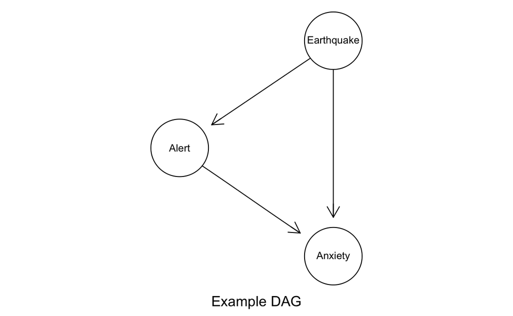

```r
# manually define a BN structure using model2network() function
dag_example = model2network("[Earthquake][Alert|Earthquake][Anxiety|Alert:Earthquake]")
# Plot the BN structure with graphviz.plot()
graphviz.plot(dag_example, sub = "Example DAG")
```

**Remark**

```r
# the order doesn't matter : the three definitions below are equivalent
model2network("[Earthquake][Alert|Earthquake][Anxiety|Alert:Earthquake]")
model2network("[Earthquake][Alert|Earthquake][Anxiety|Earthquake:Alert]")
model2network("[Earthquake][Anxiety|Alert:Earthquake][Alert|Earthquake]")
```

### Exercise 3.1

Now, it’s your turn :

**Suppose** we use the following variable names:

- `A` : Visit to Asia
- `B` : Bronchitis
- `D` : Dyspnea
- `L` : Lung Cancer
- `T` : Tuberculosis
- `S` : Smoking History
- `X` : Chest X-ray

#### Questions

**Define a BN structure (a DAG) representing the causal relationships among these variables based on your knowledge :**

- What are the causal relationships among the variables in `asia` data set ?
- Use a BN structure (a DAG) to represent your causal relationships.
- Encode in `R` your BN structure with `model2network()` and assign the output of `model2network()`, your BN structure, to `dag_mydag` (see the example above)
- Plot your BN structure with `graphviz.plot()`.

#### Solution

Following code shows one possible solution. Other BN structures are also acceptable.

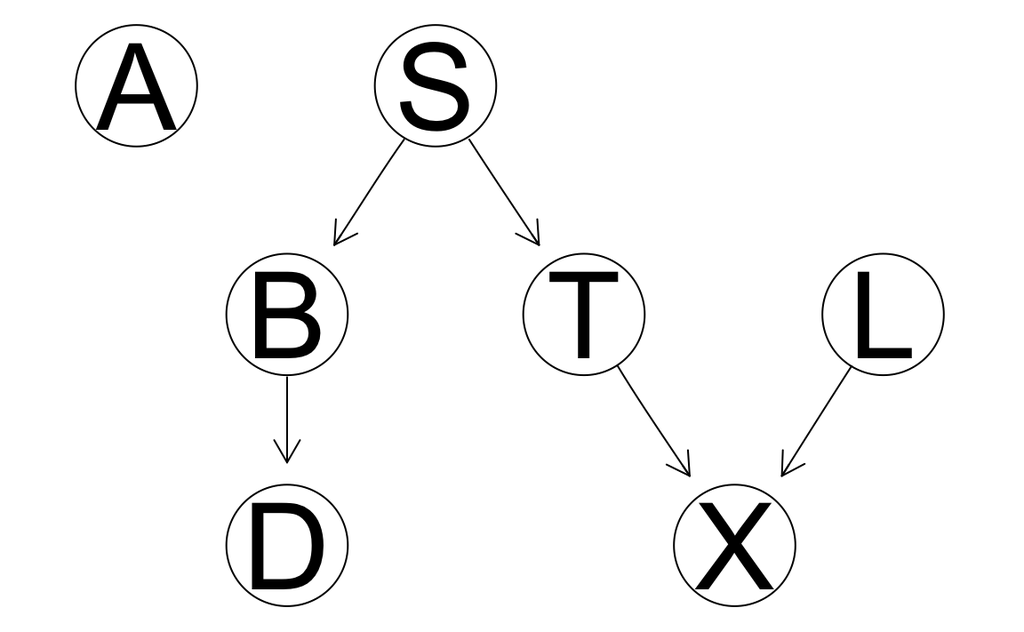

```r
# Create and plot the network structure.
dag_mydag = model2network("[A][S][T|S][L][B|S][D|B][X|L:T]")
# Plot
graphviz.plot(dag_mydag)
```

### Exercise 3.2

Consider the following piece of medical knowledge taken from [Lauritzen and Spiegelhalter, 1988]:

- Tuberculosis and lung cancer can each cause shortness of breath (dyspnea) and a positive chest X-ray.
- Bronchitis is another cause of dyspnea.
- A recent visit to Asia can increase the probability of tuberculosis.
- Smoking can cause both lung cancer and bronchitis.

#### Questions

**Create again a DAG representing the causal relationships among these variables based on upper medical knowledge**

- Encode the BN structure with `model2network()`.
- Plot this BN structure with `graphviz.plot()`.
- Plot again your BN structure and compare.

#### Solution

```r
# creat Lauritzen's BN structure
dag_Laur = model2network("[A][S][T|A][L|S][B|S][D|B:T:L][X|T:L]")
dag_Laur
```

```
#>
#>   Random/Generated Bayesian network
#>
#>   model:
#>    [A][S][B|S][L|S][T|A][D|B:L:T][X|L:T]
#>   nodes:                                 7
#>   arcs:                                  8
#>     undirected arcs:                     0
#>     directed arcs:                       8
#>   average markov blanket size:           3.14
#>   average neighbourhood size:            2.29
#>   average branching factor:              1.14
#>
#>   generation algorithm:                  Empty
```

**Remark** the generation algorithm is Empty !!

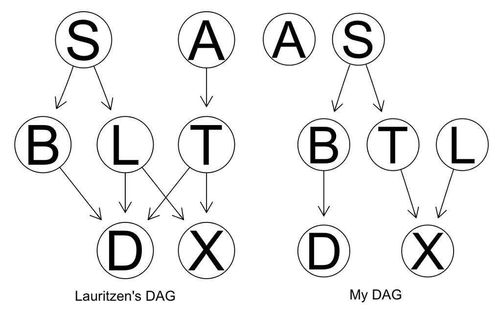

```r
par(mfrow = c(1,2))
graphviz.plot(dag_Laur, sub = "Lauritzen's DAG")
graphviz.plot(dag_mydag, sub = "My DAG")
```

## 3.2 Data-Driven Approach

### Exercise 3.3 : Score-based methods

#### Questions

- Learn a BN structure base on `asia` data set. `hc(asia)` can allow you to do this (the Hill-Climbing algorithm, which is a Score-based method, is applied)
- Plot the BN structure (output of `hc(asia)`)
- What do you observe ? Is this a DAG ?

#### Solution

```r
dag_learn_hc = hc(asia)
dag_learn_hc
```

```
#>
#>   Bayesian network learned via Score-based methods
#>
#>   model:
#>    [A][S][T][L|S][B|S][X|T:L][D|T:L:B]
#>   nodes:                                 7
#>   arcs:                                  7
#>     undirected arcs:                     0
#>     directed arcs:                       7
#>   average markov blanket size:           2.86
#>   average neighbourhood size:            2.00
#>   average branching factor:              1.00
#>
#>   learning algorithm:                    Hill-Climbing
#>   score:                                 BIC (disc.)
#>   penalization coefficient:              4.258597
#>   tests used in the learning procedure:  63
#>   optimized:                             TRUE
```

**Remark** the generation algorithm is NOT empty this time !!

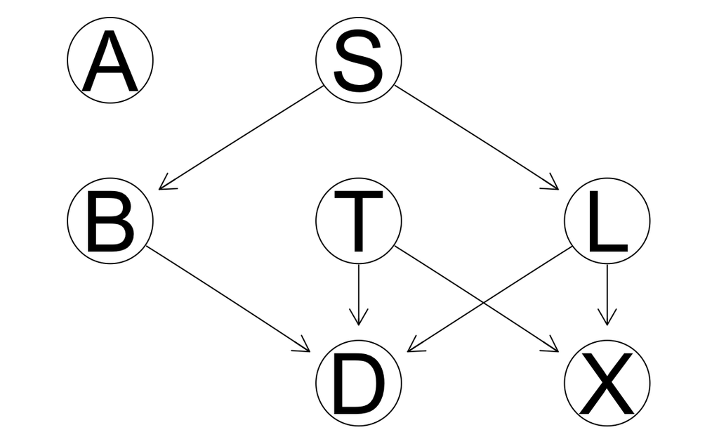

```r
graphviz.plot(dag_learn_hc)
```

## 3.3 Comparing Bayesian network structures

### Qualitative methods

#### - `compare()` function

`compare()` function compares two Bayesian network structures by listing three elements (output of `compare()`) that are the counts of:

- the true positive (`tp`) arcs, which appear both in `target` and in `current`;
- the false positive (`fp`) arcs, which appear in `current` but not in `target`;
- the false negative (`fn`) arcs, which appear in `target` but not in `current`.

```r
compare(target = dag_Laur, current = dag_mydag, arcs = TRUE)
```

```
#> $tp
#>      from to
#> [1,] "S"  "B"
#> [2,] "B"  "D"
#> [3,] "T"  "X"
#> [4,] "L"  "X"
#>
#> $fp
#>      from to
#> [1,] "S"  "T"
#>
#> $fn
#>      from to
#> [1,] "A"  "T"
#> [2,] "S"  "L"
#> [3,] "T"  "D"
#> [4,] "L"  "D"
```

#### - `graphviz.compare()` function

Another approach to compare network structures is to plot them side by side and highlight differences with different colours. `graphviz.compare()` does that using `Rgraphviz` package while taking care that the nodes have the same position for all networks, to make it easier to spot which arcs are different. As we can see below, and unlike any of the functions we covered above, `graphviz.compare()` can take more than two network structures as arguments.

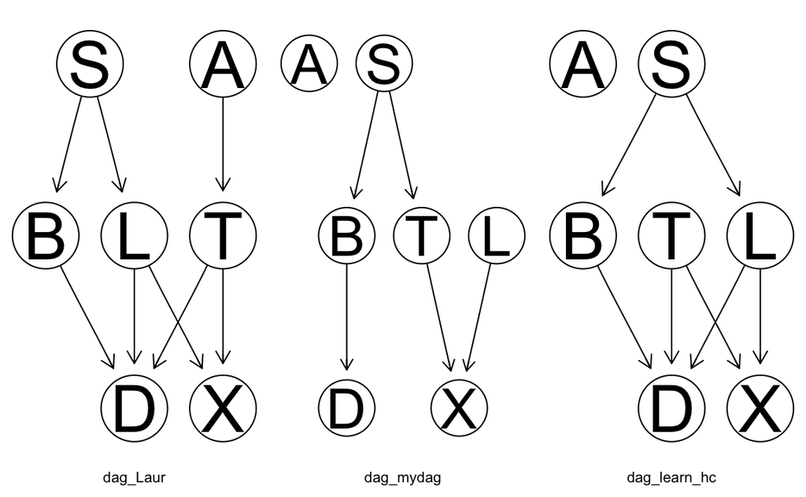

```r
par(mfrow = c(1, 3))
graphviz.plot(dag_Laur, sub = "dag_Laur")
graphviz.plot(dag_mydag, sub = "dag_mydag")
graphviz.plot(dag_learn_hc, sub = "dag_learn_hc")
```

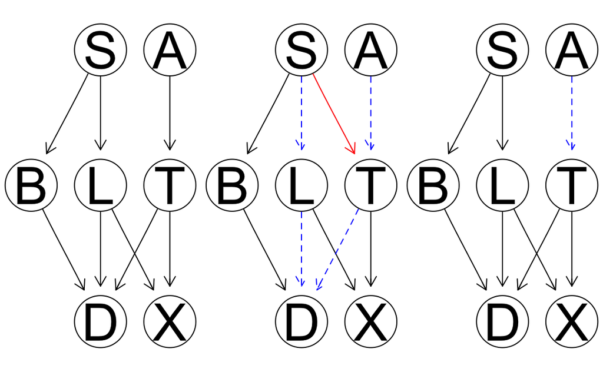

```r
par(mfrow = c(1, 3))
graphviz.compare(dag_Laur, dag_mydag, dag_learn_hc)
```

### Quantitative method

#### - `score()` function

We can compute the network score of a particular graph for a particular data set with the `score()` function (manual).

**Remark** In case the `score()` function is defined in different ways in other r packages, you should specify from which package we what to call this function. That is, if there is an error when you call `score()` function, try to replace `score()` by `bnlearn::score()` (may solve the problem) so that `R` knows you want to use the `score()` function from the `bnlearn` package.

**Remarks:**

- The number of variables in the network and in the data must be the same, although the order is not important.
- The names of the variables must match as well.

```r
score(x = dag_mydag,     data = asia)
score(x = dag_Laur,      data = asia)
score(x = dag_learn_hc,  data = asia)

# if it does not work, try bnlearn::score()

# bnlearn::score(x = dag_mydag,      data = asia)
# bnlearn::score(x = dag_Laur,       data = asia)
# bnlearn::score(x = dag_learn_hc,   data = asia)
```

[output not shown]

# 4 Exercises: Parameter Learning

In general, there are three ways of creating a `bn.fit` object representing a Bayesian network:

1. a data-driven approach, learning it from a data set using `bn.fit()` and a network structure (in a bn object) as illustrated here;
2. an expert-driven approach, in which both the network structure and the parameters are specified by the user;
3. a hybrid approach combining the above.

We will talk about the first and the third.

## 4.1 Data-driven approach

Once the structure of a DAG has been determined, the parameters can be determined as well. Two most common approaches are

- **maximum likelihood estimation (MLE)** and
- **Bayesian estimation**.

Parameter estimations are only based on the subset of data spanning the considered variable and its parents.

When using `bnlearn`, parameter learning is performed by the `bn.fit` function, which takes the network structure and the data as *arguments*.

### Exercise (Demonstration) 4.1

#### Questions

- Use `asia` data set to learn three sets of parameters based on: (`bn.fit(x = one_of_BN_Structures_of_your_choice, data = asia, method = "mle")`)
  - your BN structure
  - Lauritzen’s BN structure
  - the data-driven BN structure (output of Hill-Climbing algorithm)
- Print the output of `bn.fit()` function and find out the conditional probability table (CPT) of Lung Cancer with respect to (given) Smoking History : $\Pr(L\,|\,S) = ?$
- Calculate how much smoking causes lung cancer :

$$\frac{\Pr(L = yes \,|\,S = \text{yes})}{\Pr(L = yes \,|\,S = \text{no})} = ?$$

**Remark** As you are not given any example showing how to use `bn.fit`, type simply `?bn.fit` and try to figure it out by yourself. Otherwise, you are free to check the solution below.

#### Solution

- learn three sets of parameters

```r
# By default bn.fit use mle mthod :
# bn.fit(x, data) == bn.fit(x, data, method = "mle")
bn_mydag          = bn.fit(x = dag_mydag,     data = asia, method = "mle")
bn_dag_Laur       = bn.fit(x = dag_Laur,      data = asia, method = "mle")
bn_dag_learn_hc   = bn.fit(x = dag_learn_hc,  data = asia, method = "mle")

# Optional
# bn_mydag_bayes          = bn.fit(x = dag_mydag,     data = asia, method = "bayes")
# bn_dag_Laur_bayes       = bn.fit(x = dag_Laur,      data = asia, method = "bayes")
# bn_dag_learn_hc_bayes   = bn.fit(x = dag_learn_hc,  data = asia, method = "bayes")
```

- Print the output of `bn.fit()` function and find out the conditional probability table (CPT) of Lung Cancer with respect to (given) Smoking History : $\Pr(L\,|\,S) = ?$

```r
# You can print CPTs attached to all nodes in a given BN structure (for example bn_dag_Laur) using : `bn_dag_Laur`
# But the list of CPTs might be too long

# print just the CPT of Lung Cancer with respect to Smoking History
coef(bn_dag_Laur$L) # or simply run : bn_dag_Laur$L
```

```
#>      S
#> L             no        yes
#>   no  0.98631791 0.88230616
#>   yes 0.01368209 0.11769384
```

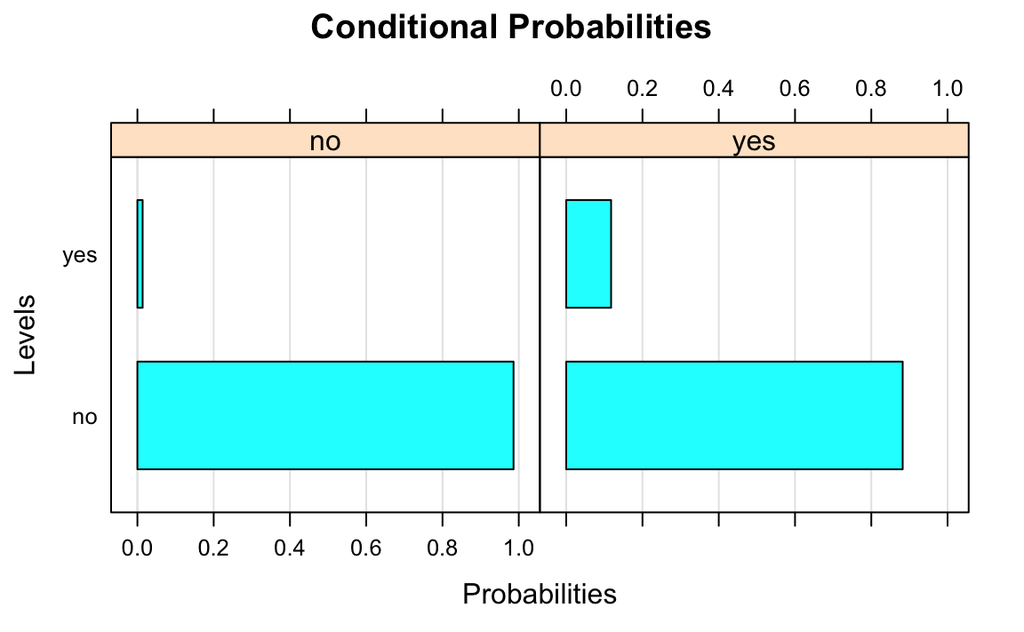

```r
# you can also represent a CPT with barchart.
bn.fit.barchart(bn_dag_Laur$L)
```

- Calculate how much smoking causes lung cancer :

$$\frac{\Pr(L = yes \,|\,S = \text{yes})}{\Pr(L = yes \,|\,S = \text{no})} =\frac{0.11769384}{0.01368209} = 8.6020348$$

[figure not shown]

## 4.2 Hybrid approach

Specifying all the local distributions can be problematic in a large network. In most cases it can be more convenient to create a `bn.fit` object from (possibly dummy) data using `bn.fit()`, and then to modify just the local distributions of the nodes of interest.

### Exercise (Demonstration) 4.2

- Creating custom fitted Bayesian networks using both data and expert knowledge.
  - For discrete Bayesian networks we can extract the conditional probability table stored in the `bn.fit` object with `coef()`, modify it, and re-save it.

#### `R` Code

```r
dag = dag_Laur
fitted = bn.fit(dag, asia)
cpt = coef(fitted$S)
# Imagine the distribution of Smoking history in a population is "no": 70% , and "yes" : 30%
cpt[1:2] = c(0.7, 0.3) # The probability distribution of node S must sum to one.
fitted$S = cpt
fitted
```

```
#>
#>   Bayesian network parameters
#>
#>   Parameters of node A (multinomial distribution)
#>
#> Conditional probability table:
#>      no    yes
#> 0.9916 0.0084
#>
#>   Parameters of node B (multinomial distribution)
#>
#> Conditional probability table:
#>
#>      S
#> B            no       yes
#>   no  0.7006036 0.2823062
#>   yes 0.2993964 0.7176938
#>
#>   Parameters of node D (multinomial distribution)
#>
#> Conditional probability table:
#>
#> , , L = no, T = no
#>
#>      B
#> D             no        yes
#>   no  0.90017286 0.21373057
#>   yes 0.09982714 0.78626943
#>
#> , , L = yes, T = no
#>
#>      B
#> D             no        yes
#>   no  0.29752066 0.13170732
#>   yes 0.70247934 0.86829268
#>
#> , , L = no, T = yes
#>
#>      B
#> D             no        yes
```

[output cut: 37 more lines]

```
#> Conditional probability table:
#>
#> , , T = no
#>
#>      L
#> X              no         yes
#>   no  0.956587473 0.006134969
#>   yes 0.043412527 0.993865031
#>
#> , , T = yes
#>
#>      L
#> X              no         yes
#>   no  0.000000000 0.000000000
#>   yes 1.000000000 1.000000000
```

# 5 Exercises: Prediction

**Inference and probability queries**

The inference engine of `bnlearn` is limited, but it can be used to test the networks and to perform basic operations with the models.

By using `cpquery()` we can ask for the probability of an `event` given a set of `evidence`. We may ask for a particular combination of configurations in the BN and a set of observed statuses for the variables in the evidence. For example, we could ask, what is the posibility of a positive cancer diagnosis for a person that smokes?, in the `asia` network.

Reference : http://jarias.es/bayesnetRtutorial/#inference_and_probability_queries

## 5.1 Conditional probability query

- Interested in the marginal posterior probability distribution of variables given evidence on other variables
- Most likely outcome (a.k.a. maximum a posteriori)
- Interested in finding the configuration of the variables that have the highest posterior probability (discrete)
- `cpquery()` estimates the conditional probability of event given evidence.
- `cpdist()` generates random observations conditional on the evidence.

**Remark**

Note that both `cpquery()` and `cpdist()` are based on Monte Carlo particle filters, and therefore they may return slightly different values on different runs.

### Example

#### - `cpquery()`

- Prior probability of `Dyspnea` being `yes`

```r
# cpquery(fitted, event, evidence, cluster = NULL, method = "ls", ..., debug = FALSE)
set.seed(20180308)
# Prior distribution of Dyspnoea
cpquery(fitted = bn_dag_Laur,
        event = (D == "yes"),
        evidence = TRUE, # evidence being true means that we have no prior evidence.
        n = 100000)
```

```
#> [1] 0.46936
```

- Posterior probability of `Dyspnea = yes` given Lung cancer being `no`

```r
# Posterior distribution of Dyspnoea given Lung cancer being "no"
cpquery(fitted = bn_dag_Laur,
        event = (D == "yes"),
        evidence = (L == "no"),
        n = 100000)
```

```
#> [1] 0.4436559
```

- Posterior probability of `Dyspnea = yes` given Lung cancer being `yes`

```r
# Posterior distribution of Dyspnoea given Lung cancer being "yes"
cpquery(fitted = bn_dag_Laur,
        event = (D == "yes"),
        evidence = (L == "yes"),
        n = 100000)
```

```
#> [1] 0.8201835
```

#### - `cpdist()`

```r
# cpdist( fitted, nodes, evidence, cluster = NULL, method = "ls", ..., debug = FALSE)
set.seed(20180308)

prop.table(
  table(
    cpdist(fitted = bn_dag_Laur,
           nodes = c("D"),
           evidence = TRUE,
           n = 100000))
)
```

```
#>
#>        no       yes
#> 0.5304898 0.4695102
```

```r
prop.table(
  table(
    cpdist(fitted = bn_dag_Laur,
           nodes = c("D"),
           evidence = (L == "no"),
           n = 100000))
)
```

```
#>
#>        no       yes
#> 0.5563441 0.4436559
```

```r
prop.table(
  table(
    cpdist(fitted = bn_dag_Laur,
           nodes = c("D"),
           evidence = (L == "yes"),
           n = 100000))
)
```

```
#>
#>        no       yes
#> 0.1765428 0.8234572
```

### Exercise 5.1

- Calculate by hand
  - $\Pr (L = yes\,|\,S = yes)$ : Probability of an individual having lung cancer
  - $\Pr (L = yes\,|\,S = no)$ : Probability of an individual having lung cancer given that he/she has **NO** smoking history.
  - $\Pr (L = yes)$
- Estimate following probabilties using `cpquery()`
  - $\hat{\Pr} (L = yes)$ : Probability of an individual having lung cancer
  - $\hat{\Pr} (L = yes\,|\,S = yes)$ : Probability of an individual having lung cancer given that he/she has smoking history
  - $\hat{\Pr} (L = yes\,|\,S = no)$ : Probability of an individual having lung cancer given that he/she has **NO** smoking history.
- Calculate the ratio between $\hat{\Pr}(L = yes\,|\,S = yes)$ and $\hat{\Pr}(L = yes\,|\,S = no)$
- Compare the ratio with “Exercise 4.1 under Section 4.1 Data-driven approach”

#### Solution

- Calculate by hand
  - $\Pr (L = yes\,|\,S = yes) = 0.11769384$ (read from `coef(bn_dag_Laur$L)`)
  - $\Pr (L = yes\,|\,S = no) = 0.01368209$ (read from `coef(bn_dag_Laur$L)`)
  - $\Pr (L = yes) = 0.11769384 \times 0.503 + 0.01368209 \times 0.497 = 0.066$

**Recall** : Law of total probability

$$\Pr(L = yes) = {\huge[} \Pr(L = yes\,|\,S = yes) \times \Pr(S = yes){\huge+}\Pr(L = yes\,|\,S = no)\times\Pr(S = no){\huge]}$$

```r
coef(bn_dag_Laur$L)
coef(bn_dag_Laur$S)
0.11769384 * 0.503 + 0.01368209 * 0.497 # sum(coef(bn_dag_Laur$L) [2,] * coef(bn_dag_Laur$S))
```

- Estimate following probabilties using `cpquery()`

```r
set.seed(20180308)

L_prior = cpquery(fitted = bn_dag_Laur,
            event = (L == "yes"),
            evidence = TRUE, # evidence being true means that we have no prior evidence.
            n = 100000)
L_prior
```

```
#> [1] 0.06608
```

```r
L_S_yes = cpquery(fitted = bn_dag_Laur,
            event = (L == "yes"),
            evidence = (S == "yes"),
            n = 100000)
L_S_yes
```

```
#> [1] 0.1177547
```

```r
L_S_no  = cpquery(fitted = bn_dag_Laur,
            event = (L == "yes"),
            evidence = (S == "no"),
            n = 100000)
L_S_no
```

```
#> [1] 0.01359477
```

```r
L_ratio = L_S_yes / L_S_no
L_ratio
```

```
#> [1] 8.661764
```

### Exercise 5.2 (Homework !!)

- Estimate following probabilties using `cpquery()`
  - $\hat{\Pr} (S)$ : Probability of an individual having smoking history
  - $\hat{\Pr} (S = yes\,|\,L = yes)$ : Probability of an individual having smoking history given that he/she has lung cancer
  - $\hat{\Pr} (S = yes\,|\,L = no)$ : Probability of an individual having smoking history given that he/she does **NOT** have lung cancer.
- Calculate the ratio between $\hat{\Pr}(S = yes \,|\,L = yes)$ and $\hat{\Pr}(S = yes\,|\,L = no)$
- Calculate (by hand) the ratio between $\Pr(S = yes \,|\,L = yes)$ and $\Pr(S = yes \,|\,L = no)$

# 6 Notes

Source: https://www.norsys.com/tutorials/netica/secA/tut_A1.htm

### Probabilities need not be exact to be useful

Some people have shied away from using Bayes nets because they imagine they will only work well, if the probabilities upon which they are based are exact. This is not true. It turns out very often that approximate probabilities, even subjective ones that are guessed at, give very good results. Bayes nets are generally quite robust to imperfect knowledge. Often the combination of several strands of imperfect knowledge can allow us to make surprisingly strong conclusions.

### Causal Conditional Probabilities are easier to estimate than the reverse

Studies have shown people are better at estimating probabilities “in the forward direction”. For example, doctors are quite good at giving the probability estimates for “if the patient has lung cancer, what are the chances their X-ray will be abnormal?”, rather than the reverse, “if the X-ray is abnormal, what are the chances of lung cancer being the cause?” (Jensen, Finn V. (1996) An Introduction to Bayesian Networks, Springer Verlag, New York.)

Back to home